# Homework 5 — Classical ML Baseline for Skin-Lesion Classification

**Student:** Daniela Gonzalez **Course:** Computer Vision and Speech Recognition — EADA **Dataset:** MILK10k (5,240 lesions, one dermoscopic + one clinical image each)

**Task.** Develop, train and evaluate a classical (non-deep) ML baseline for the project task: predict `diagnosis_1` (Benign / Indeterminate / Malignant) for each lesion. Compare different feature sets and different models, choose the best configuration, evaluate it properly and report the results.

**Protocol (reusing Sessions 1–3 and Milestone 1).**

| step | data used | purpose |
| --- | --- | --- |
| Feature extraction | every image, no labels | hand-crafted features (colour, texture, HW4 filter bank, ABCD shape, HOG) |
| 1. Feature sets × models | **train**, 5-fold `StratifiedGroupKFold` | choose the feature set and the model family |
| 2. View ablation | train, same CV | is it worth using both views? |
| 3. Hyperparameter tuning | train, nested in the same CV | tune the two best models |
| 4. Model choice | **val** (used once) | confirm the choice on unseen lesions |
| 5. Final evaluation | refit on train+val, **test** (used once) | report with 95% bootstrap CIs, confusion matrix, ROC, cost |

- **Unit = lesion.** The committed Milestone 1 splits (`splits/*.csv`, grouped by `lesion_id`) are used unchanged, so the two images of a lesion never sit on both sides of a split (the sibling leak measured in A3.1).
- **No preprocessing leak.** Imputation, scaling and one-hot encoding are inside an sklearn `Pipeline`, so they are fitted on training folds only.
- **Metric.** Primary metric is **macro-F1** (as in A3.4, accuracy is meaningless with 68% Malignant). Balanced accuracy, macro one-vs-rest AUC, per-class recall and the A3.4 **expected clinical cost** are reported alongside.
- **Imbalance.** Classes are 2,555 / 90 / 1,023 (Malignant / Indeterminate / Benign) in train; every model uses `class_weight="balanced"` (kNN has no such option, which is part of the comparison).

```python
# --- Setup -------------------------------------------------------------------
import sys
import time
import warnings
from pathlib import Path

import numpy as np
import pandas as pd
import matplotlib
matplotlib.use("Agg")
import matplotlib.pyplot as plt
from IPython.display import Image as IPyImage, display

ROOT = Path.cwd().resolve()
if not (ROOT / "milk10k_pipeline").is_dir():
    ROOT = ROOT.parent
sys.path.insert(0, str(ROOT))

from milk10k_pipeline import config
from milk10k_pipeline import baseline as bl

warnings.filterwarnings("ignore", category=UserWarning)
warnings.filterwarnings("ignore", category=FutureWarning)
pd.set_option("display.precision", 3)
pd.set_option("display.width", 160)

FIG = ROOT / "reports" / "figures_hw5"
RES = ROOT / "reports" / "hw5_results"
FIG.mkdir(parents=True, exist_ok=True)
RES.mkdir(parents=True, exist_ok=True)

# Chart style (validated categorical palette, recessive axes)
BLUE, ORANGE, AQUA, GREY = "#2a78d6", "#eb6834", "#1baf7a", "#8a8984"
INK, INK2 = "#0b0b0b", "#52514e"
plt.rcParams.update({
    "figure.facecolor": "white", "axes.facecolor": "white",
    "axes.edgecolor": "#c9c8c2", "axes.labelcolor": INK2, "text.color": INK,
    "xtick.color": INK2, "ytick.color": INK2, "axes.spines.top": False,
    "axes.spines.right": False, "axes.grid": True, "grid.color": "#ecebe6",
    "grid.linewidth": 0.8, "font.size": 10, "axes.titlesize": 11,
})
CLASS_COLOUR = {"Benign": BLUE, "Indeterminate": ORANGE, "Malignant": AQUA}
CLASSES = bl.CLASSES
print("Repository root:", ROOT.name)
```

```
Repository root: milk10k-eda
```

## 0. Data and features

Features are computed once per image by `scripts/extract_features.py` (module `milk10k_pipeline/features.py`) and cached in `data/processed/image_features.csv.gz`. Every image is resized to 224×224 (Milestone 1 `IMAGE_SIZE`) and described by five families:

| family | what it measures | link to course |
| --- | --- | --- |
| **colour** | RGB / HSV / CIE-Lab statistics, 8-bin H/S/V histograms, lesion-vs-skin ΔE, number of colours inside the lesion | Session 2 colour analysis, A3.5 hue gap |
| **texture** | GLCM (contrast, homogeneity, energy, correlation, entropy) at 3 distances, uniform LBP histograms (P=8,R=1 and P=16,R=2) | texture descriptors |
| **filter bank** | Gaussian residual, Sobel magnitude, LoG, Gabor 4 orientations × 2 frequencies, Canny edge density | Homework 4 |
| **shape** | area, eccentricity, solidity, compactness (border irregularity), asymmetry along both principal axes of a rough lesion mask | ABCD rule |
| **HOG** | 324-dim histogram of oriented gradients on a 64×64 grey image | local gradient structure |

Each lesion gets the features of **both** views (`derm__…`, `clin__…`) concatenated, so the lesion is the classification unit. Metadata (age, sex, anatomical site) can be added as a separate feature set.

```python
lesions = bl.load_lesion_table()
train = lesions[lesions.split == "train"].reset_index(drop=True)
val = lesions[lesions.split == "val"].reset_index(drop=True)
test = lesions[lesions.split == "test"].reset_index(drop=True)

print("lesion table:", lesions.shape)
dist = (lesions.groupby(["split", "diagnosis_1"]).size().unstack()
        .loc[["train", "val", "test"], CLASSES])
dist["total"] = dist.sum(axis=1)
display(dist)

n_feats = {name: len(bl.feature_columns(lesions, fams, views, meta))
           for name, (fams, views, meta) in bl.FEATURE_SETS.items()}
display(pd.Series(n_feats, name="n_columns").to_frame())
```

```
lesion table: (5240, 977)
```

| diagnosis_1 split | Benign | Indeterminate | Malignant | total |
| --- | --- | --- | --- | --- |
| train | 1023 | 90 | 2555 | 3668 |
| val | 223 | 20 | 543 | 786 |
| test | 237 | 13 | 536 | 786 |

|  | n_columns |
| --- | --- |
| meta only | 3 |
| colour | 164 |
| texture (GLCM+LBP) | 94 |
| filter bank (HW4) | 48 |
| shape (ABCD) | 14 |
| HOG | 648 |
| hand-crafted (C+T+F+S) | 320 |
| hand-crafted + HOG | 968 |
| hand-crafted + meta | 323 |
| all (hand-crafted+HOG+meta) | 971 |

The shape and colour-contrast features need a lesion mask. A rough, training-free mask is used (Otsu threshold on the blurred grey image, keeping the connected component closest to the centre). It works well on dark, well-delimited lesions (melanoma) and badly on pink, low-contrast ones (BCC, AKIEC, many clinical photos), which is a known limitation of this baseline and one of the reasons a learned model should beat it.

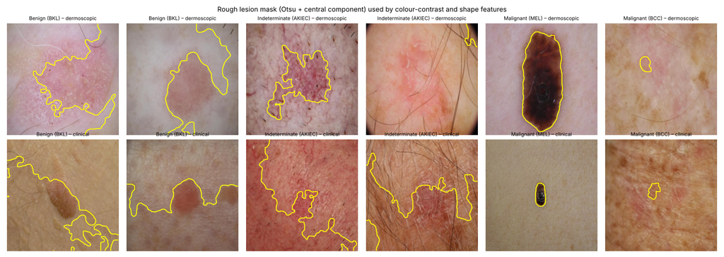

```python
display(IPyImage(filename=str(FIG / "fig1_lesion_masks.png"), width=1000))
```

### Reference points: dummy classifiers

Same four dummies as A3.4, recomputed on the Milestone 1 val and test splits. Any model must clearly beat these.

```python
from sklearn.dummy import DummyClassifier

dummy_rows = []
for split_name, df in [("val", val), ("test", test)]:
    y = df["diagnosis_1"].values
    for name, clf in {
        "always-Malignant": DummyClassifier(strategy="constant", constant="Malignant"),
        "always-Benign": DummyClassifier(strategy="constant", constant="Benign"),
        "stratified-random": DummyClassifier(strategy="stratified", random_state=0),
        "uniform-random": DummyClassifier(strategy="uniform", random_state=0),
    }.items():
        clf.fit(np.zeros((len(train), 1)), train["diagnosis_1"])
        p = clf.predict(np.zeros((len(y), 1)))
        m = bl.metrics(y, p)
        dummy_rows.append({"split": split_name, "dummy": name, **m})
dummies = pd.DataFrame(dummy_rows)
dummies.to_csv(RES / "dummies.csv", index=False)
display(dummies[["split", "dummy", "macro_f1", "balanced_acc", "accuracy",
                 "recall_Malignant", "cost_per_lesion"]])
```

|  | split | dummy | macro_f1 | balanced_acc | accuracy | recall_Malignant | cost_per_lesion |
| --- | --- | --- | --- | --- | --- | --- | --- |
| 0 | val | always-Malignant | 0.272 | 0.333 | 0.691 | 1.000 | 0.411 |
| 1 | val | always-Benign | 0.147 | 0.333 | 0.284 | 0.000 | 34.669 |
| 2 | val | stratified-random | 0.325 | 0.325 | 0.542 | 0.683 | 10.382 |
| 3 | val | uniform-random | 0.269 | 0.339 | 0.335 | 0.335 | 13.375 |
| 4 | test | always-Malignant | 0.270 | 0.333 | 0.682 | 1.000 | 0.384 |
| 5 | test | always-Benign | 0.154 | 0.333 | 0.302 | 0.000 | 34.179 |
| 6 | test | stratified-random | 0.326 | 0.324 | 0.561 | 0.703 | 9.776 |
| 7 | test | uniform-random | 0.280 | 0.388 | 0.346 | 0.334 | 12.715 |

## 1. Feature sets × models (5-fold CV on train)

Ten feature sets × five model families = 50 configurations, each evaluated with the same 5-fold `StratifiedGroupKFold` (grouped by `lesion_id`, stratified on `diagnosis_1`, `seed=0`). Models use sensible defaults here; only the winners are tuned in step 3, which keeps the comparison fair and cheap.

| model | why it is in the comparison |
| --- | --- |
| Logistic regression (L2, C=0.1) | linear reference, well calibrated |
| SVM with RBF kernel | classic strong baseline on standardised hand-crafted features |
| k-NN (k=15, distance-weighted) | non-parametric; shows the cost of having no class weighting |
| Random forest (400 trees) | robust to irrelevant/correlated features, gives importances |
| Histogram gradient boosting | strongest tabular learner in sklearn |

```python
GRID_CSV = RES / "cv_grid.csv"
RERUN = not GRID_CSV.exists()

if RERUN:
    rows = []
    t0 = time.time()
    for fs_name, (fams, views, meta) in bl.FEATURE_SETS.items():
        cols = bl.feature_columns(lesions, fams, views, meta)
        for m_name, model in bl.make_models().items():
            r = bl.cross_validate_config(train, cols, model)
            r.pop("oof_proba")
            rows.append({"feature_set": fs_name, "model": m_name,
                         "n_features": len(cols), **r})
            print(f"{fs_name:30s} {m_name:13s} macro-F1 {r['macro_f1_mean']:.3f} "
                  f"± {r['macro_f1_std']:.3f}   [{time.time() - t0:.0f}s]")
    grid = pd.DataFrame(rows)
    grid.to_csv(GRID_CSV, index=False)
else:
    grid = pd.read_csv(GRID_CSV)
    print("Loaded cached CV grid from", GRID_CSV.relative_to(ROOT))
```

```
Loaded cached CV grid from reports/hw5_results/cv_grid.csv
```

```python
order_fs = list(bl.FEATURE_SETS)
order_m = list(bl.make_models())
pivot_f1 = grid.pivot(index="feature_set", columns="model", values="macro_f1_mean").loc[order_fs, order_m]
pivot_sd = grid.pivot(index="feature_set", columns="model", values="macro_f1_std").loc[order_fs, order_m]
pivot_ba = grid.pivot(index="feature_set", columns="model", values="balanced_acc_mean").loc[order_fs, order_m]

print("Macro-F1, mean over 5 folds (train CV)")
display(pivot_f1.round(3))
print("Balanced accuracy, mean over 5 folds (train CV)")
display(pivot_ba.round(3))

top = (grid.sort_values("macro_f1_mean", ascending=False)
       [["feature_set", "model", "n_features", "macro_f1_mean", "macro_f1_std",
         "balanced_acc_mean", "macro_auc_mean", "recall_Malignant_mean",
         "recall_Indeterminate_mean", "cost_per_lesion_mean"]].head(10))
print("Top 10 configurations by CV macro-F1")
display(top.reset_index(drop=True))
```

```
Macro-F1, mean over 5 folds (train CV)
```

| model feature_set | LogReg | SVM-RBF | kNN | RandomForest | HistGB |
| --- | --- | --- | --- | --- | --- |
| meta only | 0.409 | 0.421 | 0.427 | 0.434 | 0.405 |
| colour | 0.479 | 0.521 | 0.440 | 0.489 | 0.566 |
| texture (GLCM+LBP) | 0.508 | 0.546 | 0.537 | 0.556 | 0.567 |
| filter bank (HW4) | 0.486 | 0.505 | 0.455 | 0.499 | 0.535 |
| shape (ABCD) | 0.409 | 0.453 | 0.444 | 0.454 | 0.489 |
| HOG | 0.470 | 0.526 | 0.440 | 0.460 | 0.529 |
| hand-crafted (C+T+F+S) | 0.540 | 0.576 | 0.520 | 0.552 | 0.581 |
| hand-crafted + HOG | 0.525 | 0.589 | 0.515 | 0.482 | 0.574 |
| hand-crafted + meta | 0.551 | 0.589 | 0.526 | 0.550 | 0.601 |
| all (hand-crafted+HOG+meta) | 0.534 | 0.591 | 0.523 | 0.478 | 0.581 |

```
Balanced accuracy, mean over 5 folds (train CV)
```

| model feature_set | LogReg | SVM-RBF | kNN | RandomForest | HistGB |
| --- | --- | --- | --- | --- | --- |
| meta only | 0.595 | 0.582 | 0.423 | 0.581 | 0.558 |
| colour | 0.579 | 0.572 | 0.435 | 0.472 | 0.567 |
| texture (GLCM+LBP) | 0.654 | 0.638 | 0.497 | 0.515 | 0.570 |
| filter bank (HW4) | 0.630 | 0.587 | 0.432 | 0.468 | 0.549 |
| shape (ABCD) | 0.521 | 0.491 | 0.440 | 0.448 | 0.505 |
| HOG | 0.503 | 0.515 | 0.433 | 0.451 | 0.514 |
| hand-crafted (C+T+F+S) | 0.628 | 0.591 | 0.488 | 0.514 | 0.571 |
| hand-crafted + HOG | 0.552 | 0.563 | 0.482 | 0.467 | 0.552 |
| hand-crafted + meta | 0.641 | 0.602 | 0.493 | 0.514 | 0.596 |
| all (hand-crafted+HOG+meta) | 0.561 | 0.564 | 0.488 | 0.466 | 0.560 |

```
Top 10 configurations by CV macro-F1
```

|  | feature_set | model | n_features | macro_f1_mean | macro_f1_std | balanced_acc_mean | macro_auc_mean | recall_Malignant_mean | recall_Indeterminate_mean | cost_per_lesion_mean |
| --- | --- | --- | --- | --- | --- | --- | --- | --- | --- | --- |
| 0 | hand-crafted + meta | HistGB | 323 | 0.601 | 0.017 | 0.596 | 0.825 | 0.847 | 0.289 | 5.130 |
| 1 | all (hand-crafted+HOG+meta) | SVM-RBF | 971 | 0.591 | 0.044 | 0.564 | 0.819 | 0.840 | 0.167 | 5.742 |
| 2 | hand-crafted + HOG | SVM-RBF | 968 | 0.589 | 0.045 | 0.563 | 0.817 | 0.835 | 0.167 | 5.919 |
| 3 | hand-crafted + meta | SVM-RBF | 323 | 0.589 | 0.012 | 0.602 | 0.825 | 0.813 | 0.311 | 5.988 |
| 4 | hand-crafted (C+T+F+S) | HistGB | 320 | 0.581 | 0.028 | 0.571 | 0.814 | 0.836 | 0.233 | 5.591 |
| 5 | all (hand-crafted+HOG+meta) | HistGB | 971 | 0.581 | 0.018 | 0.560 | 0.812 | 0.864 | 0.189 | 4.734 |
| 6 | hand-crafted (C+T+F+S) | SVM-RBF | 320 | 0.576 | 0.012 | 0.591 | 0.820 | 0.802 | 0.289 | 6.296 |
| 7 | hand-crafted + HOG | HistGB | 968 | 0.574 | 0.022 | 0.552 | 0.813 | 0.856 | 0.167 | 5.080 |
| 8 | texture (GLCM+LBP) | HistGB | 94 | 0.567 | 0.012 | 0.570 | 0.774 | 0.811 | 0.278 | 6.237 |
| 9 | colour | HistGB | 164 | 0.566 | 0.033 | 0.567 | 0.795 | 0.824 | 0.233 | 5.883 |

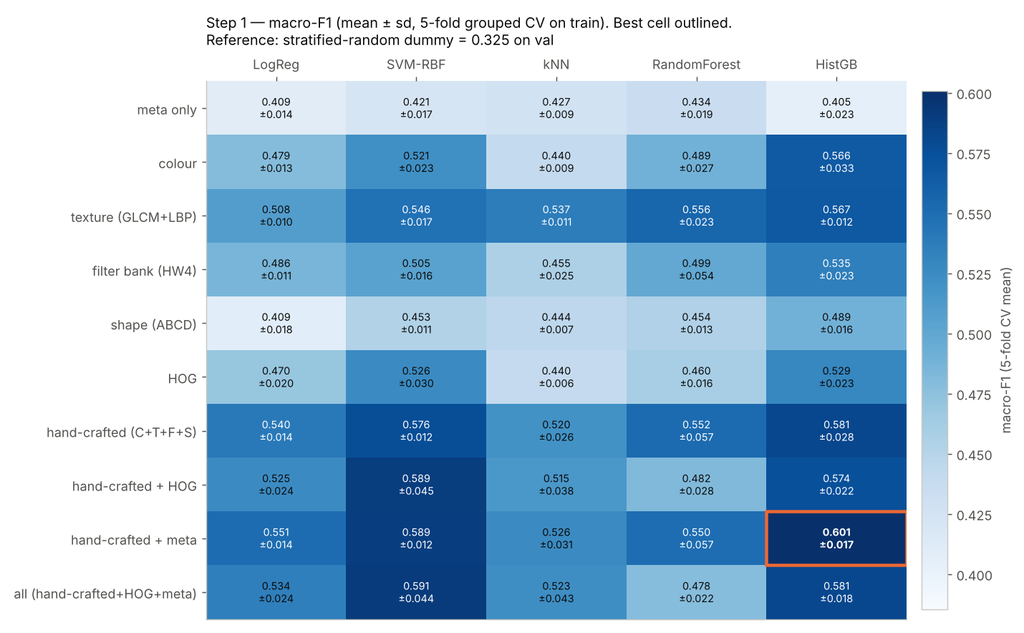

```python
STRAT_VAL_F1 = dummies.query("split == 'val' and dummy == 'stratified-random'").macro_f1.iat[0]
fig, ax = plt.subplots(figsize=(11, 6.8))
im = ax.imshow(pivot_f1.values, cmap="Blues", aspect="auto",
               vmin=pivot_f1.values.min() - 0.02, vmax=pivot_f1.values.max())
ax.grid(False)
ax.set_xticks(range(len(order_m)), order_m)
ax.set_yticks(range(len(order_fs)), order_fs)
best_rc = np.unravel_index(np.nanargmax(pivot_f1.values), pivot_f1.shape)
for i in range(pivot_f1.shape[0]):
    for j in range(pivot_f1.shape[1]):
        v, s = pivot_f1.iat[i, j], pivot_sd.iat[i, j]
        dark = v > np.nanpercentile(pivot_f1.values, 65)
        ax.text(j, i, f"{v:.3f}\n±{s:.3f}", ha="center", va="center", fontsize=8,
                color="white" if dark else INK,
                fontweight="bold" if (i, j) == best_rc else "normal")
ax.add_patch(plt.Rectangle((best_rc[1] - 0.5, best_rc[0] - 0.5), 1, 1,
                           fill=False, ec=ORANGE, lw=2.5))
cb = fig.colorbar(im, ax=ax, fraction=0.035, pad=0.02)
cb.set_label("macro-F1 (5-fold CV mean)")
ax.xaxis.tick_top()
ax.set_title("Step 1 — macro-F1 (mean ± sd, 5-fold grouped CV on train). Best cell outlined.\n"
             f"Reference: stratified-random dummy = {STRAT_VAL_F1:.3f} on val", loc="left", pad=28)
plt.tight_layout()
plt.savefig(FIG / "fig2_cv_grid_macro_f1.png", dpi=130)
plt.close()
display(IPyImage(filename=str(FIG / "fig2_cv_grid_macro_f1.png"), width=850))
```

### Step 1 — Findings

- **Every image-based configuration beats every dummy by a wide margin** (best dummy macro-F1 on val: 0.325). Even metadata alone (age, sex, site) reaches 0.41–0.43, so the metadata signal from A3.1 is real but small.
- **Feature families.** Individually, texture (GLCM + LBP, best 0.567) and colour (0.566) are the most informative, followed by the HW4 filter bank (0.535), HOG (0.529) and shape (0.489). Combining the four hand-crafted families (320 features) is better than any single family (0.581), and adding the 3 metadata columns helps further (**0.601**).
- **HOG does not pay off.** Adding 648 HOG columns to the hand-crafted set hurts HistGB and the random forest (0.552 → 0.482) and only helps SVM marginally, with 3× more variance across folds (±0.045). HOG captures *where* gradients are, which is not stable across lesions that are not aligned or scaled consistently.
- **Models.** Gradient boosting (HistGB) is the best or tied-best model on 7 of 10 feature sets, SVM-RBF is a close second and much more stable on high-dimensional sets. k-NN is worst almost everywhere: it has no class weighting, so it ignores the 90 Indeterminate lesions. Logistic regression has the best *balanced accuracy* on several sets (e.g. 0.654 on texture) because class weights push it to predict Indeterminate often, but its precision there is poor, so its macro-F1 is lower.

**Choice:** feature set **hand-crafted + meta** (323 columns); the two best model families on it, **HistGB** (0.601 ± 0.017) and **SVM-RBF** (0.589 ± 0.012), go to tuning. The differences inside the top-5 are about one fold standard deviation, which is why both are kept.

## 2. View ablation: dermoscopic, clinical, or both?

Using the best feature families and the best model family from step 1, the same CV is repeated with only the dermoscopic image, only the clinical image, and both.

```
Best from step 1: feature set = 'hand-crafted + meta', model = 'HistGB', CV macro-F1 = 0.601
```

|  | views | n_features | macro_f1_mean | macro_f1_std | balanced_acc_mean | macro_auc_mean |
| --- | --- | --- | --- | --- | --- | --- |
| 0 | dermoscopic only | 163 | 0.586 | 0.032 | 0.596 | 0.829 |
| 1 | clinical only | 163 | 0.550 | 0.021 | 0.551 | 0.794 |
| 2 | both views | 323 | 0.601 | 0.017 | 0.596 | 0.825 |

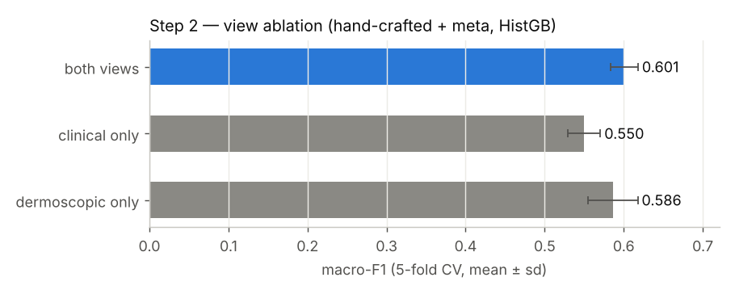

```python
best = grid.sort_values("macro_f1_mean", ascending=False).iloc[0]
BEST_FS, BEST_MODEL = best["feature_set"], best["model"]
best_fams, _, best_meta = bl.FEATURE_SETS[BEST_FS]
print(f"Best from step 1: feature set = {BEST_FS!r}, model = {BEST_MODEL!r}, "
      f"CV macro-F1 = {best['macro_f1_mean']:.3f}")

view_rows = []
for label_, views in [("dermoscopic only", ("derm",)), ("clinical only", ("clin",)),
                      ("both views", ("derm", "clin"))]:
    cols = bl.feature_columns(lesions, best_fams, views, best_meta)
    r = bl.cross_validate_config(train, cols, bl.make_models()[BEST_MODEL])
    view_rows.append({"views": label_, "n_features": len(cols),
                      **{k: r[k] for k in ["macro_f1_mean", "macro_f1_std",
                                           "balanced_acc_mean", "macro_auc_mean"]}})
views_df = pd.DataFrame(view_rows)
views_df.to_csv(RES / "view_ablation.csv", index=False)
display(views_df)

fig, ax = plt.subplots(figsize=(7, 2.8))
ax.barh(views_df["views"], views_df["macro_f1_mean"], xerr=views_df["macro_f1_std"],
        color=[GREY, GREY, BLUE], height=0.55, error_kw=dict(ecolor=INK2, lw=1, capsize=3))
for i, v in enumerate(views_df["macro_f1_mean"]):
    ax.text(v + views_df["macro_f1_std"].iat[i] + 0.005, i, f"{v:.3f}", va="center", color=INK)
ax.set_xlabel("macro-F1 (5-fold CV, mean ± sd)")
ax.set_xlim(0, views_df["macro_f1_mean"].max() + 0.12)
ax.grid(axis="y", visible=False)
ax.set_title(f"Step 2 — view ablation ({BEST_FS}, {BEST_MODEL})", loc="left")
plt.tight_layout()
plt.savefig(FIG / "fig3_view_ablation.png", dpi=130)
plt.close()
display(IPyImage(filename=str(FIG / "fig3_view_ablation.png"), width=650))
```

### Step 2 — Findings

The dermoscopic image alone (0.586) is clearly better than the clinical close-up alone (0.550): dermoscopy removes surface reflection and shows pigment structures, which the colour and texture features pick up. Using **both views gives the highest score (0.601)** with the smallest fold sd, but the gain over dermoscopic-only (+0.015) is within the run-to-run noise measured in the robustness check at the end of the notebook (re-running on features rounded to 6 significant digits moved these two numbers by up to 0.014). The safe conclusion is: the clinical view alone is clearly weaker, and adding it to the dermoscopic view does not hurt and probably helps a little (step 6 confirms that the clinical colour and texture blocks are used by the final model). Both views are kept, consistent with the Milestone 1 decision to make the lesion, not the image, the unit.

## 3. Hyperparameter tuning of the two best model families

The two best model families on the best feature set are tuned with `GridSearchCV` using the same grouped 5-fold CV on train and `scoring="f1_macro"`. Grids are deliberately small (≤ 12 settings) to limit selection noise on 90 Indeterminate training lesions.

```python
from sklearn.model_selection import GridSearchCV, StratifiedGroupKFold

BEST_COLS = bl.feature_columns(lesions, best_fams, ("derm", "clin"), best_meta)
fs_rank = (grid[grid.feature_set == BEST_FS].sort_values("macro_f1_mean", ascending=False))
TOP2 = fs_rank["model"].head(2).tolist()
print("Tuning:", TOP2, "on", BEST_FS, f"({len(BEST_COLS)} features)")

n_num = len([c for c in BEST_COLS if c not in bl.META_CAT])
PARAM_GRIDS = {
    "LogReg": {"model__C": [0.003, 0.01, 0.03, 0.1, 0.3, 1.0]},
    "SVM-RBF": {"model__C": [0.3, 1, 3, 10],
                "model__gamma": [0.3 / n_num, 1.0 / n_num, 3.0 / n_num]},
    "kNN": {"model__n_neighbors": [5, 15, 31, 61]},
    "RandomForest": {"model__min_samples_leaf": [1, 3, 10],
                     "model__max_features": ["sqrt", 0.1]},
    "HistGB": {"model__learning_rate": [0.03, 0.1],
               "model__max_leaf_nodes": [15, 31],
               "model__l2_regularization": [0.0, 1.0]},
}

cv = StratifiedGroupKFold(n_splits=5, shuffle=True, random_state=config.SEED)
TUNE_CSV = RES / "tuning.csv"
tuned, tune_rows = {}, []
if TUNE_CSV.exists():
    # Re-use the cached grid-search result (it takes ~35 min on a laptop)
    import ast
    tune_df = pd.read_csv(TUNE_CSV)
    for _, r in tune_df.iterrows():
        params = {f"model__{k}": v for k, v in ast.literal_eval(r["best_params"]).items()}
        tuned[r["model"]] = bl.make_pipeline(bl.make_models()[r["model"]], BEST_COLS).set_params(**params)
    print("Loaded cached tuning results from", TUNE_CSV.relative_to(ROOT))
for m_name in ([] if TUNE_CSV.exists() else TOP2):
    gs = GridSearchCV(bl.make_pipeline(bl.make_models()[m_name], BEST_COLS),
                      PARAM_GRIDS[m_name], scoring="f1_macro", cv=cv, n_jobs=1, refit=True)
    t0 = time.time()
    gs.fit(train[BEST_COLS], train["diagnosis_1"], groups=train["lesion_id"])
    tuned[m_name] = gs.best_estimator_
    default_f1 = fs_rank.set_index("model").loc[m_name, "macro_f1_mean"]
    tune_rows.append({"model": m_name, "default_cv_macro_f1": default_f1,
                      "tuned_cv_macro_f1": gs.best_score_,
                      "best_params": {k.replace("model__", ""): v for k, v in gs.best_params_.items()},
                      "seconds": round(time.time() - t0)})
if tune_rows:
    tune_df = pd.DataFrame(tune_rows)
    tune_df.to_csv(TUNE_CSV, index=False)
display(tune_df)
```

```
Tuning: ['HistGB', 'SVM-RBF'] on hand-crafted + meta (323 features)
Loaded cached tuning results from reports/hw5_results/tuning.csv
```

|  | model | default_cv_macro_f1 | tuned_cv_macro_f1 | best_params | seconds |
| --- | --- | --- | --- | --- | --- |
| 0 | HistGB | 0.601 | 0.611 | {'l2_regularization': 0.0, 'learning_rate': 0.... | 1686 |
| 1 | SVM-RBF | 0.589 | 0.591 | {'C': 1, 'gamma': 0.003115264797507788} | 507 |

### Step 3 — Findings

Tuning gives a small gain for HistGB (0.601 → **0.611**, with `learning_rate=0.1`, `max_leaf_nodes=15`, no L2) and essentially none for SVM-RBF (0.589 → 0.591, `C=1`, `gamma≈1/n_features`, i.e. the defaults were already good). Gains of 0.01 are within one fold sd: the defaults were reasonable, and most of the performance comes from the features, not from the hyperparameters.

## 4. Choose the final configuration on the validation split

Candidates: the two tuned models and their soft-voting ensemble (average of predicted probabilities). Each is fitted on **train** and scored once on **val** (786 lesions). The candidate with the highest val macro-F1 becomes the final model.

```python
from sklearn.ensemble import VotingClassifier
from sklearn.base import clone

candidates = dict(tuned)
candidates[f"Ensemble({TOP2[0]}+{TOP2[1]})"] = VotingClassifier(
    [(n, clone(p)) for n, p in tuned.items()], voting="soft")

val_rows, fitted = [], {}
for name, est in candidates.items():
    est = clone(est).fit(train[BEST_COLS], train["diagnosis_1"])
    fitted[name] = est
    m, _, _ = bl.evaluate(est, val, BEST_COLS)
    val_rows.append({"candidate": name, **m})
val_df = pd.DataFrame(val_rows).sort_values("macro_f1", ascending=False)
val_df.to_csv(RES / "val_candidates.csv", index=False)
display(val_df)

FINAL_NAME = val_df.iloc[0]["candidate"]
print("Final configuration:", FINAL_NAME, "on", BEST_FS)

# Screening threshold on P(Malignant) for >= 95% Malignant sensitivity,
# chosen on VAL with the train-fitted model (never on test)
proba_val = fitted[FINAL_NAME].predict_proba(val[BEST_COLS])
T95 = bl.threshold_for_sensitivity(val["diagnosis_1"], proba_val[:, 2], 0.95)
print(f"Threshold on P(Malignant) for 95% sensitivity on val: {T95:.3f}")
```

|  | candidate | macro_f1 | balanced_acc | accuracy | recall_Benign | recall_Indeterminate | recall_Malignant | f1_Benign | f1_Indeterminate | f1_Malignant | cost_per_lesion | macro_auc |
| --- | --- | --- | --- | --- | --- | --- | --- | --- | --- | --- | --- | --- |
| 2 | Ensemble(HistGB+SVM-RBF) | 0.563 | 0.547 | 0.793 | 0.673 | 0.10 | 0.867 | 0.674 | 0.160 | 0.855 | 4.616 | 0.806 |
| 1 | SVM-RBF | 0.547 | 0.558 | 0.767 | 0.709 | 0.15 | 0.814 | 0.662 | 0.140 | 0.840 | 5.969 | 0.817 |
| 0 | HistGB | 0.539 | 0.543 | 0.771 | 0.709 | 0.10 | 0.821 | 0.665 | 0.111 | 0.841 | 5.940 | 0.787 |

```
Final configuration: Ensemble(HistGB+SVM-RBF) on hand-crafted + meta
```

```
Threshold on P(Malignant) for 95% sensitivity on val: 0.289
```

### Step 4 — Findings

On val, the **soft-voting ensemble of tuned HistGB + SVM-RBF** has the best macro-F1 (0.563 vs 0.547 SVM and 0.539 HistGB), the best accuracy, the best Malignant recall (0.867) and the lowest clinical cost (4.6 per lesion), so it is the final model. Averaging the probabilities of a tree ensemble and a kernel machine reduces the variance of each.

Val scores are lower than the CV scores (≈0.56 vs ≈0.60). The gap is almost entirely the **Indeterminate** class: only 20 val lesions, of which the ensemble finds 2. With so few examples, Indeterminate F1 moves by ~0.05 for every single lesion, and macro-F1 gives it one third of the weight.

## 5. Final evaluation on the test split

The chosen configuration is refitted on **train + val** (4,454 lesions) with the hyperparameters fixed in step 3, then scored **once** on the 786 test lesions. 95% confidence intervals come from 1,000 bootstrap resamples of the test lesions.

1. **argmax** — the class with the highest predicted probability (what the model was selected for, macro-F1);
2. **screening (95% sensitivity)** — call Malignant whenever P(Malignant) ≥ t, with t chosen on **val** so that 95% of val Malignant lesions are caught (a typical clinical requirement);
3. **cost-optimal** — the Bayes decision rule under the A3.4 cost matrix (missing a Malignant costs 50, an unnecessary work-up 1, any Indeterminate error 5): predict the class with the lowest expected cost given the probabilities.

No parameter is chosen on test.

```python
trainval = pd.concat([train, val], ignore_index=True)
final = clone(candidates[FINAL_NAME]).fit(trainval[BEST_COLS], trainval["diagnosis_1"])

y_test = test["diagnosis_1"].values
proba_test = final.predict_proba(test[BEST_COLS])
assert list(final.classes_) == CLASSES
pred_argmax = np.array(CLASSES)[proba_test.argmax(axis=1)]
pred_screen = bl.threshold_predict(proba_test, T95)
pred_cost = bl.cost_optimal_predict(proba_test)

ci_argmax = bl.bootstrap_ci(y_test, pred_argmax, proba_test)
ci_screen = bl.bootstrap_ci(y_test, pred_screen, proba_test)
ci_cost = bl.bootstrap_ci(y_test, pred_cost, proba_test)
ci_argmax.to_csv(RES / "test_metrics_argmax_ci.csv")
ci_screen.to_csv(RES / "test_metrics_screening95_ci.csv")
ci_cost.to_csv(RES / "test_metrics_costoptimal_ci.csv")


def fmt(ci):
    return ci.apply(lambda r: f"{r.value:.3f} [{r.ci_low:.3f}, {r.ci_high:.3f}]", axis=1)


test_table = pd.DataFrame({"argmax": fmt(ci_argmax), "screening 95%": fmt(ci_screen),
                           "cost-optimal": fmt(ci_cost)})
d_test = dummies.query("split == 'test'").set_index("dummy")
for d in ["always-Malignant", "stratified-random"]:
    test_table[d] = d_test.loc[d, test_table.index.drop("macro_auc")].map("{:.3f}".format)
test_table.loc["macro_auc", ["always-Malignant", "stratified-random"]] = "0.500"
print(f"TEST (786 lesions) — {FINAL_NAME} on {BEST_FS}; value [95% bootstrap CI]")
display(test_table)
test_table.to_csv(RES / "test_summary_table.csv")

# Where does the val -> test difference come from? Per-class F1 side by side
val_final_metrics = bl.metrics(val["diagnosis_1"], fitted[FINAL_NAME].predict(val[BEST_COLS]), proba_val)
per_class = pd.DataFrame({
    "val (fit on train)": {k: val_final_metrics[k] for k in ["f1_Benign", "f1_Indeterminate", "f1_Malignant", "macro_f1"]},
    "test (fit on train+val)": {k: ci_argmax.loc[k, "value"] for k in ["f1_Benign", "f1_Indeterminate", "f1_Malignant", "macro_f1"]},
})
per_class.loc["n Indeterminate lesions"] = [int((val.diagnosis_1 == "Indeterminate").sum()),
                                            int((test.diagnosis_1 == "Indeterminate").sum())]
display(per_class)
```

```
TEST (786 lesions) — Ensemble(HistGB+SVM-RBF) on hand-crafted + meta; value [95% bootstrap CI]
```

|  | argmax | screening 95% | cost-optimal | always-Malignant | stratified-random |
| --- | --- | --- | --- | --- | --- |
| macro_f1 | 0.697 [0.589, 0.787] | 0.644 [0.526, 0.745] | 0.457 [0.344, 0.542] | 0.270 | 0.326 |
| balanced_acc | 0.644 [0.556, 0.745] | 0.575 [0.494, 0.678] | 0.462 [0.375, 0.556] | 0.333 | 0.324 |
| accuracy | 0.818 [0.791, 0.844] | 0.804 [0.777, 0.832] | 0.688 [0.655, 0.721] | 0.682 | 0.561 |
| recall_Benign | 0.641 [0.580, 0.702] | 0.443 [0.379, 0.508] | 0.000 [0.000, 0.000] | 0.000 | 0.270 |
| recall_Indeterminate | 0.385 [0.125, 0.667] | 0.308 [0.077, 0.600] | 0.385 [0.125, 0.667] | 0.000 | 0.000 |
| recall_Malignant | 0.907 [0.882, 0.930] | 0.976 [0.962, 0.987] | 1.000 [1.000, 1.000] | 1.000 | 0.703 |
| f1_Benign | 0.692 [0.642, 0.738] | 0.590 [0.526, 0.651] | 0.000 [0.000, 0.000] | 0.000 | 0.284 |
| f1_Indeterminate | 0.526 [0.200, 0.783] | 0.471 [0.143, 0.750] | 0.556 [0.222, 0.800] | 0.000 | 0.000 |
| f1_Malignant | 0.873 [0.852, 0.892] | 0.872 [0.852, 0.893] | 0.814 [0.790, 0.836] | 0.811 | 0.693 |
| cost_per_lesion | 3.282 [2.520, 4.138] | 1.052 [0.655, 1.542] | 0.352 [0.305, 0.405] | 0.384 | 9.776 |
| macro_auc | 0.879 [0.844, 0.909] | 0.879 [0.844, 0.909] | 0.879 [0.844, 0.909] | 0.500 | 0.500 |

|  | val (fit on train) | test (fit on train+val) |
| --- | --- | --- |
| f1_Benign | 0.674 | 0.692 |
| f1_Indeterminate | 0.160 | 0.526 |
| f1_Malignant | 0.855 | 0.873 |
| macro_f1 | 0.563 | 0.697 |
| n Indeterminate lesions | 20.000 | 13.000 |

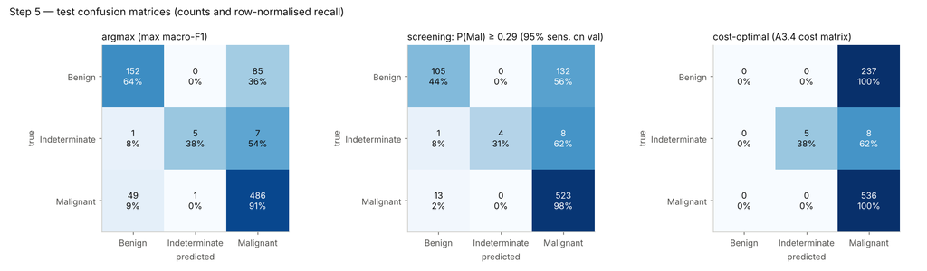

```python
cm_a = bl.confusion(y_test, pred_argmax)
cm_s = bl.confusion(y_test, pred_screen)
cm_c = bl.confusion(y_test, pred_cost)
cm_a.to_csv(RES / "test_confusion_argmax.csv")
cm_s.to_csv(RES / "test_confusion_screening95.csv")
cm_c.to_csv(RES / "test_confusion_costoptimal.csv")

fig, axes = plt.subplots(1, 3, figsize=(15, 4.4))
for ax, cm, title in [(axes[0], cm_a, "argmax (max macro-F1)"),
                      (axes[1], cm_s, f"screening: P(Mal) ≥ {T95:.2f} (95% sens. on val)"),
                      (axes[2], cm_c, "cost-optimal (A3.4 cost matrix)")]:
    rown = cm.values / cm.values.sum(axis=1, keepdims=True)
    ax.imshow(rown, cmap="Blues", vmin=0, vmax=1)
    ax.grid(False)
    for i in range(3):
        for j in range(3):
            ax.text(j, i, f"{cm.values[i, j]}\n{rown[i, j]:.0%}", ha="center", va="center",
                    color="white" if rown[i, j] > 0.55 else INK, fontsize=10)
    ax.set_xticks(range(3), CLASSES)
    ax.set_yticks(range(3), CLASSES)
    ax.set_xlabel("predicted")
    ax.set_ylabel("true")
    ax.set_title(title, loc="left")
fig.suptitle("Step 5 — test confusion matrices (counts and row-normalised recall)", x=0.01,
             ha="left", fontsize=12)
plt.tight_layout()
plt.savefig(FIG / "fig4_test_confusion.png", dpi=130)
plt.close()
display(IPyImage(filename=str(FIG / "fig4_test_confusion.png"), width=1000))
```

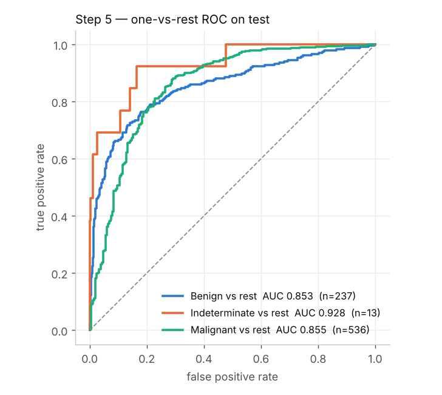

```python
from sklearn.metrics import roc_curve, roc_auc_score

fig, ax = plt.subplots(figsize=(5.6, 5))
for k, c in enumerate(CLASSES):
    yk = (y_test == c).astype(int)
    fpr, tpr, _ = roc_curve(yk, proba_test[:, k])
    auc = roc_auc_score(yk, proba_test[:, k])
    ax.plot(fpr, tpr, lw=2, color=CLASS_COLOUR[c], label=f"{c} vs rest  AUC {auc:.3f}  (n={yk.sum()})")
ax.plot([0, 1], [0, 1], ls="--", lw=1, color=GREY)
ax.set_xlabel("false positive rate")
ax.set_ylabel("true positive rate")
ax.set_aspect("equal")
ax.legend(loc="lower right", frameon=False, fontsize=9)
ax.set_title("Step 5 — one-vs-rest ROC on test", loc="left")
plt.tight_layout()
plt.savefig(FIG / "fig5_test_roc.png", dpi=130)
plt.close()
display(IPyImage(filename=str(FIG / "fig5_test_roc.png"), width=520))
```

### Step 5 — Findings (test, 786 lesions, used once)

**Argmax operating point.** Macro-F1 **0.697** [95% CI 0.589–0.787], balanced accuracy 0.644, accuracy 0.818, macro AUC **0.879** [0.844–0.909]. Malignant recall is 0.907 (486/536), Benign recall 0.641 (152/237), and 5 of 13 Indeterminate lesions are found. Compared with the best dummy (macro-F1 0.33, AUC 0.50), the baseline is clearly useful, and the lower ends of every CI are well above the dummies.

**Val vs test.** Test macro-F1 is higher than val (0.70 vs 0.56). The per-class table shows that Benign and Malignant F1 are similar on both splits; the difference is Indeterminate (13 test lesions vs 20 val lesions), where 3 extra correct lesions move F1 a lot. The final model was also refitted on 21% more data. The wide CI (≈ ±0.10) is the honest summary: **the expected macro-F1 of this baseline is about 0.6–0.7**, and the CV estimate (0.61) is the most reliable single number.

**Clinical operating points.** The argmax rule still misses 49 malignant lesions (9%), which costs 3.3 per lesion under the A3.4 matrix — *worse* than the trivial always-Malignant rule (0.38). With the **screening threshold** P(Malignant) ≥ 0.289 (chosen on val for 95% sensitivity), test Malignant recall is **0.976** [0.962, 0.987] (523/536, 13 missed) while **105 of 237 benign lesions (44%) are still correctly spared** a work-up; cost drops to 1.05 per lesion and macro-F1 stays at 0.644. This is the most useful operating point of the baseline as a triage tool. The Bayes cost-optimal rule, however, never calls a lesion Benign: with a 50:1 cost ratio a lesion should be cleared only when P(Malignant) < 1/51 ≈ 2%, and a classical model on hand-crafted features is never that confident. Under that cost matrix the baseline can only marginally beat "biopsy everything" (0.352 vs 0.384). **This is the key gap a deep model in Milestone 2 has to close**: not average accuracy but confident, well-calibrated rule-out of benign lesions.

## 6. What does the model rely on? Grouped permutation importance

Each feature family of each view is permuted **as a block** (all its columns shuffled together across lesions, 5 repeats) and the drop in macro-F1 on **val** is measured, using the candidate fitted on train in step 4. Block permutation avoids the problem that single correlated features (e.g. GLCM at three distances) hide each other's importance.

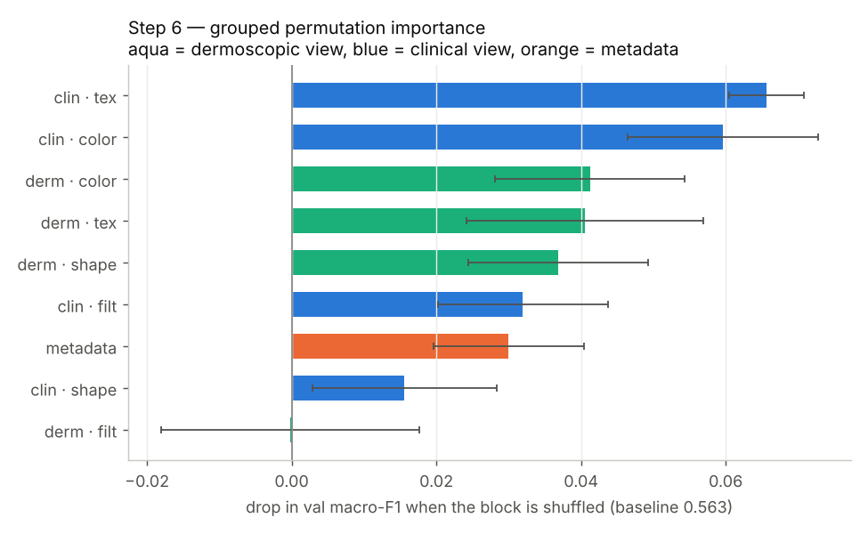

|  | group | n_cols | f1_drop_mean | f1_drop_std |
| --- | --- | --- | --- | --- |
| 0 | clin · tex | 47 | 6.568e-02 | 0.005 |
| 1 | clin · color | 82 | 5.961e-02 | 0.013 |
| 2 | derm · color | 82 | 4.123e-02 | 0.013 |
| 3 | derm · tex | 47 | 4.053e-02 | 0.016 |
| 4 | derm · shape | 7 | 3.688e-02 | 0.012 |
| 5 | clin · filt | 24 | 3.197e-02 | 0.012 |
| 6 | metadata | 3 | 3.000e-02 | 0.010 |
| 7 | clin · shape | 7 | 1.559e-02 | 0.013 |
| 8 | derm · filt | 24 | -1.840e-04 | 0.018 |

```python
imp_model = fitted[FINAL_NAME]
groups = {}
for v, vname in [("derm", "derm"), ("clin", "clin")]:
    for fam in best_fams:
        groups[f"{vname} · {fam}"] = bl.feature_columns(lesions, [fam], (v,), False)
if best_meta:
    groups["metadata"] = bl.META_NUM + bl.META_CAT

rng = np.random.default_rng(config.SEED)
base = bl.metrics(val["diagnosis_1"], imp_model.predict(val[BEST_COLS]))["macro_f1"]
imp_rows = []
for gname, gcols in groups.items():
    drops = []
    for _ in range(5):
        Xp = val[BEST_COLS].copy()
        perm = rng.permutation(len(Xp))
        Xp[gcols] = Xp[gcols].values[perm]
        drops.append(base - bl.metrics(val["diagnosis_1"], imp_model.predict(Xp))["macro_f1"])
    imp_rows.append({"group": gname, "n_cols": len(gcols),
                     "f1_drop_mean": np.mean(drops), "f1_drop_std": np.std(drops)})
imp = pd.DataFrame(imp_rows).sort_values("f1_drop_mean")
imp.to_csv(RES / "permutation_importance_groups.csv", index=False)

fig, ax = plt.subplots(figsize=(7.5, 0.38 * len(imp) + 1.2))
ax.barh(imp["group"], imp["f1_drop_mean"], xerr=imp["f1_drop_std"], height=0.6,
        color=[AQUA if g.startswith("derm") else (ORANGE if g == "metadata" else BLUE)
               for g in imp["group"]], error_kw=dict(ecolor=INK2, lw=1, capsize=2))
ax.axvline(0, color=GREY, lw=1)
ax.grid(axis="y", visible=False)
ax.set_xlabel(f"drop in val macro-F1 when the block is shuffled (baseline {base:.3f})")
ax.set_title("Step 6 — grouped permutation importance\n"
             "aqua = dermoscopic view, blue = clinical view, orange = metadata", loc="left")
plt.tight_layout()
plt.savefig(FIG / "fig6_permutation_importance.png", dpi=130)
plt.close()
display(IPyImage(filename=str(FIG / "fig6_permutation_importance.png"), width=700))
display(imp.sort_values("f1_drop_mean", ascending=False).reset_index(drop=True))
```

```python
# Save everything needed to reproduce the summary
pd.Series({"threshold_P_malignant_95sens_val": T95}).to_csv(RES / "screening_threshold.csv")
pd.Series({"best_feature_set": BEST_FS, "best_model_step1": BEST_MODEL,
           "tuned_models": ", ".join(TOP2), "final": FINAL_NAME,
           "n_features": len(BEST_COLS)}).to_csv(RES / "final_choice.csv")
print("Saved results to", RES.relative_to(ROOT))
print(sorted(p.name for p in RES.iterdir()))
```

[output not shown]

### Step 6 — Findings

Every block except the dermoscopic filter bank contributes. **Texture and colour of both views are the most important** (shuffling clinical texture alone drops val macro-F1 by 0.066), followed by dermoscopic shape (asymmetry/border), the clinical filter bank and metadata. The dermoscopic HW4 filter-bank block is redundant once texture is present: Sobel, LoG and Gabor energy on the dermoscopic image measure the same fine structure as GLCM and LBP. The importance of the clinical view is larger here than its standalone score in step 2 suggested, which again says the two views are complementary.

## 7. Conclusions

**Final baseline.** Soft-voting ensemble of a tuned histogram gradient boosting classifier and an RBF SVM, on 323 hand-crafted features (colour, GLCM/LBP texture, HW4 filter bank and ABCD-style shape, from both the dermoscopic and the clinical image, plus age, sex and site).

|  | macro-F1 | balanced acc. | macro AUC | Malignant recall |
| --- | --- | --- | --- | --- |
| 5-fold CV on train (tuned HistGB) | 0.611 | — | — | — |
| val (fit on train) | 0.563 | 0.547 | 0.806 | 0.867 |
| **test** (fit on train+val) | **0.697** [0.589, 0.787] | 0.644 | **0.879** | 0.907 |
| test, screening threshold (t = 0.289 from val) | 0.644 | 0.575 | 0.879 | **0.976** |
| best dummy on test | 0.326 | 0.388 | 0.500 | — |

**What was learned.**

1. Colour and texture are the most useful hand-crafted cues; shape and HOG add little; metadata adds a small, consistent gain.
2. The dermoscopic view is the stronger one alone; adding the clinical view gives a small gain that is within the noise of the CV estimate.
3. Gradient boosting and SVM-RBF are the best classical models; k-NN suffers from the class imbalance, and adding many weak features (HOG) hurts tree models.
4. Most model choices differ by less than one CV standard deviation, and test CIs are ±0.10 wide because Indeterminate has 13 test lesions. Results must be read with their uncertainty.
5. As a triage tool at 97.6% Malignant sensitivity it still spares 44% of benign lesions, but under the strict 50:1 cost matrix it cannot rule out malignancy confidently, so the cost-optimal rule degenerates to "refer everything".

**Limitations.** The lesion mask is a rough Otsu threshold that fails on pink, low-contrast lesions (BCC, AKIEC), which weakens the shape and colour-contrast features. Class weights make probabilities uncalibrated, which matters for the threshold and cost rules. Indeterminate is too small for reliable estimates.

**Robustness check (run separately, not shown as a cell because it needs a second feature extraction).** Re-running steps 2–5 with the image features rounded to 6 significant digits — a perturbation far below any meaningful image difference — changed the view-ablation CV macro-F1 by up to 0.014 (both views 0.601 → 0.587, dermoscopic only 0.586 → 0.593) and the test macro-F1 from 0.697 to 0.722 (balanced accuracy 0.644 → 0.670, macro AUC 0.879 → 0.876, Malignant recall 0.907 in both). Gradient boosting's histogram binning makes it sensitive to tiny input changes. Conclusion: **differences below about 0.02 macro-F1 between configurations should not be interpreted**; the large effects (image features ≫ metadata ≫ dummies; colour and texture > shape and HOG; k-NN worst; clinical-only weaker than dermoscopic-only; test macro-F1 roughly 0.7 and AUC roughly 0.88) are stable.

**Next steps (Milestone 2).** Train a CNN with the Milestone 1 `LesionDataset` (two views) and compare it to this baseline with the same splits, metrics and cost matrix. Calibrate the probabilities (`CalibratedClassifierCV` / temperature scaling) before choosing an operating point, and report sensitivity at a fixed 95% as the clinical headline number.